# DDK Modelling spatial variability

# 6 Exploratory testing

## 6.1 Compare different predictors

```r
summary(mPace <- bam(temp_var ~ s(pace) + groupO + s(subj,bs='re'), data = df, family =Gamma(link=log)), select = T, discrete = T, nthreads = 10)
```

```
##
## Family: Gamma
## Link function: log
##
## Formula:
## temp_var ~ s(pace) + groupO + s(subj, bs = "re")
##
## Parametric coefficients:
##               Estimate Std. Error t value Pr(>|t|)
## (Intercept)    2.85684    0.08656  33.005  < 2e-16 ***
## groupOtypical -0.43199    0.11845  -3.647 0.000304 ***
## ---
## Signif. codes:  0 '***' 0.001 '**' 0.01 '*' 0.05 '.' 0.1 ' ' 1
##
## Approximate significance of smooth terms:
##           edf Ref.df     F p-value
## s(pace)  1.00      1 2.799  0.0952 .
## s(subj) 32.48     40 4.862  <2e-16 ***
## ---
## Signif. codes:  0 '***' 0.001 '**' 0.01 '*' 0.05 '.' 0.1 ' ' 1
##
## R-sq.(adj) =  0.343   Deviance explained = 47.9%
## fREML = 292.91  Scale est. = 0.20743   n = 397
```

```r
summary(mSpeed <- bam(temp_var ~ s(mean.speed2target) + groupO + s(subj,bs='re'), data = df, family =Gamma(link=log)), select = T, discrete = T, nthreads = 10)
```

```
##
## Family: Gamma
## Link function: log
##
## Formula:
## temp_var ~ s(mean.speed2target) + groupO + s(subj, bs = "re")
##
## Parametric coefficients:
##               Estimate Std. Error t value Pr(>|t|)
## (Intercept)    2.80161    0.07915  35.394  < 2e-16 ***
## groupOtypical -0.35584    0.10828  -3.286  0.00112 **
## ---
## Signif. codes:  0 '***' 0.001 '**' 0.01 '*' 0.05 '.' 0.1 ' ' 1
##
## Approximate significance of smooth terms:
##                         edf Ref.df     F  p-value
## s(mean.speed2target)  2.463  3.053 9.222 7.07e-06 ***
## s(subj)              31.549 40.000 4.156  < 2e-16 ***
## ---
## Signif. codes:  0 '***' 0.001 '**' 0.01 '*' 0.05 '.' 0.1 ' ' 1
##
## R-sq.(adj) =  0.376   Deviance explained = 50.4%
## fREML = 280.95  Scale est. = 0.19659   n = 397
```

```r
summary(mStiffness <- bam(temp_var ~ s(mean.stiffness2target) + groupO + s(subj,bs='re'), data = df, family =Gamma(link=log)), select = T, discrete = T, nthreads = 10)
```

```
##
## Family: Gamma
## Link function: log
##
## Formula:
## temp_var ~ s(mean.stiffness2target) + groupO + s(subj, bs = "re")
##
## Parametric coefficients:
##               Estimate Std. Error t value Pr(>|t|)
## (Intercept)    2.86980    0.08664  33.122  < 2e-16 ***
## groupOtypical -0.45923    0.11883  -3.864 0.000132 ***
## ---
## Signif. codes:  0 '***' 0.001 '**' 0.01 '*' 0.05 '.' 0.1 ' ' 1
##
## Approximate significance of smooth terms:
##                             edf Ref.df     F p-value
## s(mean.stiffness2target)  1.932   2.45 0.651    0.69
## s(subj)                  32.351  40.00 4.822  <2e-16 ***
## ---
## Signif. codes:  0 '***' 0.001 '**' 0.01 '*' 0.05 '.' 0.1 ' ' 1
##
## R-sq.(adj) =   0.35   Deviance explained = 47.8%
## fREML = 294.26  Scale est. = 0.20834   n = 397
```

```r
summary(mDist2target <- bam(temp_var ~ s(mean.dist2target) + groupO + s(subj,bs='re'), data = df, family =Gamma(link=log)), select = T, discrete = T, nthreads = 10)
```

```
##
## Family: Gamma
## Link function: log
##
## Formula:
## temp_var ~ s(mean.dist2target) + groupO + s(subj, bs = "re")
##
## Parametric coefficients:
##               Estimate Std. Error t value Pr(>|t|)
## (Intercept)    2.83931    0.08319  34.130  < 2e-16 ***
## groupOtypical -0.41766    0.11325  -3.688 0.000261 ***
## ---
## Signif. codes:  0 '***' 0.001 '**' 0.01 '*' 0.05 '.' 0.1 ' ' 1
##
## Approximate significance of smooth terms:
##                        edf Ref.df     F p-value
## s(mean.dist2target)  1.756   2.16 5.533 0.00353 **
## s(subj)             32.186  40.00 4.665 < 2e-16 ***
## ---
## Signif. codes:  0 '***' 0.001 '**' 0.01 '*' 0.05 '.' 0.1 ' ' 1
##
## R-sq.(adj) =  0.369   Deviance explained = 48.9%
## fREML = 287.56  Scale est. = 0.20228   n = 397
```

```r
summary(mTime2target <- bam(temp_var ~ s(mean.time2target) + groupO + s(subj,bs='re'), data = df, family =Gamma(link=log)), select = T, discrete = T, nthreads = 10)
```

```
##
## Family: Gamma
## Link function: log
##
## Formula:
## temp_var ~ s(mean.time2target) + groupO + s(subj, bs = "re")
##
## Parametric coefficients:
##               Estimate Std. Error t value Pr(>|t|)
## (Intercept)    2.84598    0.08806   32.32  < 2e-16 ***
## groupOtypical -0.41488    0.12095   -3.43 0.000673 ***
## ---
## Signif. codes:  0 '***' 0.001 '**' 0.01 '*' 0.05 '.' 0.1 ' ' 1
##
## Approximate significance of smooth terms:
##                        edf Ref.df     F p-value
## s(mean.time2target)  1.733   2.16 2.111   0.139
## s(subj)             32.661  40.00 4.967  <2e-16 ***
## ---
## Signif. codes:  0 '***' 0.001 '**' 0.01 '*' 0.05 '.' 0.1 ' ' 1
##
## R-sq.(adj) =  0.353   Deviance explained = 48.6%
## fREML = 291.52  Scale est. = 0.20471   n = 397
```

```r
summary(mGestdur <- bam(temp_var ~ s(mean.gest.dur) + groupO + s(subj,bs='re'), data = df, family =Gamma(link=log)), select = T, discrete = T, nthreads = 10)
```

```
##
## Family: Gamma
## Link function: log
##
## Formula:
## temp_var ~ s(mean.gest.dur) + groupO + s(subj, bs = "re")
##
## Parametric coefficients:
##               Estimate Std. Error t value Pr(>|t|)
## (Intercept)     2.8456     0.0895  31.795  < 2e-16 ***
## groupOtypical  -0.4264     0.1229  -3.469 0.000587 ***
## ---
## Signif. codes:  0 '***' 0.001 '**' 0.01 '*' 0.05 '.' 0.1 ' ' 1
##
## Approximate significance of smooth terms:
##                     edf Ref.df     F p-value
## s(mean.gest.dur)  4.056  5.028 2.711  0.0201 *
## s(subj)          32.785 40.000 5.254  <2e-16 ***
## ---
## Signif. codes:  0 '***' 0.001 '**' 0.01 '*' 0.05 '.' 0.1 ' ' 1
##
## R-sq.(adj) =  0.373   Deviance explained = 50.4%
## fREML = 288.16  Scale est. = 0.19726   n = 397
```

```r
summary(mPeakvel <- bam(temp_var ~ s(mean.peakvel2target) + groupO + s(subj,bs='re'), data = df, family =Gamma(link=log)), select = T, discrete = T, nthreads = 10)
```

```
##
## Family: Gamma
## Link function: log
##
## Formula:
## temp_var ~ s(mean.peakvel2target) + groupO + s(subj, bs = "re")
##
## Parametric coefficients:
##               Estimate Std. Error t value Pr(>|t|)
## (Intercept)    2.80687    0.08016  35.014  < 2e-16 ***
## groupOtypical -0.36369    0.10960  -3.318 0.000998 ***
## ---
## Signif. codes:  0 '***' 0.001 '**' 0.01 '*' 0.05 '.' 0.1 ' ' 1
##
## Approximate significance of smooth terms:
##                           edf Ref.df     F  p-value
## s(mean.peakvel2target)  2.311  2.859 8.352 5.07e-05 ***
## s(subj)                31.697 40.000 4.263  < 2e-16 ***
## ---
## Signif. codes:  0 '***' 0.001 '**' 0.01 '*' 0.05 '.' 0.1 ' ' 1
##
## R-sq.(adj) =  0.372   Deviance explained = 49.9%
## fREML = 282.88  Scale est. = 0.19833   n = 397
```

```r
summary(mAccphase <- bam(temp_var ~ s(mean.dur.accphase) + groupO + s(subj,bs='re'), data = df, family =Gamma(link=log)), select = T, discrete = T, nthreads = 10)
```

```
##
## Family: Gamma
## Link function: log
##
## Formula:
## temp_var ~ s(mean.dur.accphase) + groupO + s(subj, bs = "re")
##
## Parametric coefficients:
##               Estimate Std. Error t value Pr(>|t|)
## (Intercept)     2.8596     0.0871  32.830  < 2e-16 ***
## groupOtypical  -0.4385     0.1199  -3.658 0.000292 ***
## ---
## Signif. codes:  0 '***' 0.001 '**' 0.01 '*' 0.05 '.' 0.1 ' ' 1
##
## Approximate significance of smooth terms:
##                        edf Ref.df     F p-value
## s(mean.dur.accphase)  1.00      1 0.497   0.481
## s(subj)              32.52     40 4.845  <2e-16 ***
## ---
## Signif. codes:  0 '***' 0.001 '**' 0.01 '*' 0.05 '.' 0.1 ' ' 1
##
## R-sq.(adj) =  0.347   Deviance explained = 47.6%
## fREML = 294.08  Scale est. = 0.20873   n = 397
```

```r
summary(mDecphase <- bam(temp_var ~ s(mean.dur.decphase) + groupO + s(subj,bs='re'), data = df, family =Gamma(link=log)), select = T, discrete = T, nthreads = 10)
```

```
##
## Family: Gamma
## Link function: log
##
## Formula:
## temp_var ~ s(mean.dur.decphase) + groupO + s(subj, bs = "re")
##
## Parametric coefficients:
##               Estimate Std. Error t value Pr(>|t|)
## (Intercept)    2.84728    0.08782  32.422  < 2e-16 ***
## groupOtypical -0.42058    0.12008  -3.503 0.000519 ***
## ---
## Signif. codes:  0 '***' 0.001 '**' 0.01 '*' 0.05 '.' 0.1 ' ' 1
##
## Approximate significance of smooth terms:
##                         edf Ref.df     F p-value
## s(mean.dur.decphase)  2.679  3.387 2.781  0.0311 *
## s(subj)              32.790 40.000 5.098  <2e-16 ***
## ---
## Signif. codes:  0 '***' 0.001 '**' 0.01 '*' 0.05 '.' 0.1 ' ' 1
##
## R-sq.(adj) =  0.366   Deviance explained = 49.5%
## fREML = 288.63  Scale est. = 0.20024   n = 397
```

```r
AIC(mPace)
```

```
## [1] 2527.631
```

```r
AIC(mSpeed)
```

```
## [1] 2509.604
```

```r
AIC(mStiffness)
```

```
## [1] 2532.771
```

```r
AIC(mDist2target)
```

```
## [1] 2522.13
```

```r
AIC(mTime2target)
```

```
## [1] 2527.854
```

```r
AIC(mGestdur)
```

```
## [1] 2515.897
```

```r
AIC(mPeakvel)
```

```
## [1] 2513.059
```

```r
AIC(mAccphase)
```

```
## [1] 2530.424
```

```r
AIC(mDecphase)
```

```
## [1] 2520.68
```

Speed has the lowest AIC.

Check if the model has improved

```r
summary(mSpeedML <- bam(temp_var ~ s(mean.speed2target) + groupO + s(subj,bs='re'), data = df, family = Gamma(link=log), method = "ML"))
```

```
##
## Family: Gamma
## Link function: log
##
## Formula:
## temp_var ~ s(mean.speed2target) + groupO + s(subj, bs = "re")
##
## Parametric coefficients:
##               Estimate Std. Error t value Pr(>|t|)
## (Intercept)    2.80195    0.07725  36.271  < 2e-16 ***
## groupOtypical -0.35624    0.10560  -3.373 0.000823 ***
## ---
## Signif. codes:  0 '***' 0.001 '**' 0.01 '*' 0.05 '.' 0.1 ' ' 1
##
## Approximate significance of smooth terms:
##                         edf Ref.df      F  p-value
## s(mean.speed2target)  2.097    2.6 10.582 1.19e-05 ***
## s(subj)              31.181   40.0  4.113  < 2e-16 ***
## ---
## Signif. codes:  0 '***' 0.001 '**' 0.01 '*' 0.05 '.' 0.1 ' ' 1
##
## R-sq.(adj) =  0.375   Deviance explained = 50.1%
## -ML = 276.12  Scale est. = 0.19705   n = 397
```

```r
compareML(mFinalHypothesis_gamma2ML, mSpeedML)
```

```
## mFinalHypothesis_gamma2ML: temp_var ~ groupO + s(subj, bs = "re")
##
## mSpeedML: temp_var ~ s(mean.speed2target) + groupO + s(subj, bs = "re")
##
## Chi-square test of ML scores
## -----
##                       Model    Score Edf Difference    Df   p.value Sig.
## 1 mFinalHypothesis_gamma2ML 288.8661   3
## 2                  mSpeedML 276.1237   5     12.742 2.000 2.924e-06  ***
##
## AIC difference: 19.16, model mSpeedML has lower AIC.
```

Yes.

Plot smooth:

```
## Summary:
##  * groupO : factor; set to the value(s): typical.
##  * mean.speed2target : numeric predictor; with 30 values ranging from 0.009868 to 0.228102.
##  * subj : factor; set to the value(s): CTRL01. (Might be canceled as random effect, check below.)
##  * NOTE : The following random effects columns are canceled: s(subj)
##
```

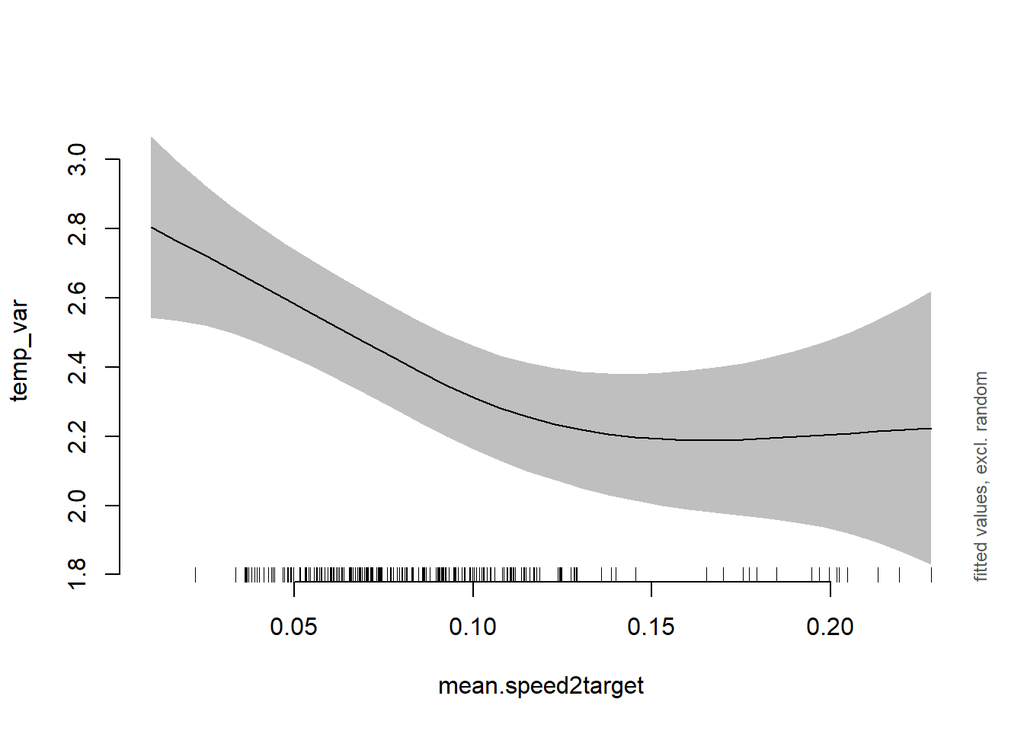

```r
plot_smooth(mSpeed, view = "mean.speed2target")
```

Variable pattern, note that most of the data is between 0 and 0.15.

Add random smooth over speed:

```r
summary(m1 <- bam(temp_var ~ s(mean.speed2target) + groupO + s(mean.speed2target, subj, bs = "fs", m=1, k = 11), data = df, family =Gamma(link=log), discrete = T, nthreads = 10))
```

```
##
## Family: Gamma
## Link function: log
##
## Formula:
## temp_var ~ s(mean.speed2target) + groupO + s(mean.speed2target,
##     subj, bs = "fs", m = 1, k = 11)
##
## Parametric coefficients:
##               Estimate Std. Error t value Pr(>|t|)
## (Intercept)    2.79054    0.08057  34.635  < 2e-16 ***
## groupOtypical -0.35221    0.10919  -3.226  0.00138 **
## ---
## Signif. codes:  0 '***' 0.001 '**' 0.01 '*' 0.05 '.' 0.1 ' ' 1
##
## Approximate significance of smooth terms:
##                              edf  Ref.df     F  p-value
## s(mean.speed2target)       2.201   2.636 8.213 7.17e-05 ***
## s(mean.speed2target,subj) 46.110 360.000 0.549  < 2e-16 ***
## ---
## Signif. codes:  0 '***' 0.001 '**' 0.01 '*' 0.05 '.' 0.1 ' ' 1
##
## R-sq.(adj) =  0.404   Deviance explained = 54.8%
## fREML = 272.71  Scale est. = 0.18215   n = 397
```

Yes.

Add seg?

```r
summary(m1ML <- bam(temp_var ~ s(mean.speed2target) + groupO + s(mean.speed2target, subj, bs = "fs", m=1, k = 11), data = df, family =Gamma(link=log), discrete = T, nthreads = 10))
```

```
##
## Family: Gamma
## Link function: log
##
## Formula:
## temp_var ~ s(mean.speed2target) + groupO + s(mean.speed2target,
##     subj, bs = "fs", m = 1, k = 11)
##
## Parametric coefficients:
##               Estimate Std. Error t value Pr(>|t|)
## (Intercept)    2.79054    0.08057  34.635  < 2e-16 ***
## groupOtypical -0.35221    0.10919  -3.226  0.00138 **
## ---
## Signif. codes:  0 '***' 0.001 '**' 0.01 '*' 0.05 '.' 0.1 ' ' 1
##
## Approximate significance of smooth terms:
##                              edf  Ref.df     F  p-value
## s(mean.speed2target)       2.201   2.636 8.213 7.17e-05 ***
## s(mean.speed2target,subj) 46.110 360.000 0.549  < 2e-16 ***
## ---
## Signif. codes:  0 '***' 0.001 '**' 0.01 '*' 0.05 '.' 0.1 ' ' 1
##
## R-sq.(adj) =  0.404   Deviance explained = 54.8%
## fREML = 272.71  Scale est. = 0.18215   n = 397
```

```r
summary(m1seg <- bam(temp_var ~ segO + s(mean.speed2target) + groupO + s(mean.speed2target, subj, bs = "fs", m=1, k = 11), data = df, family =Gamma(link=log), discrete = T, nthreads = 10))
```

```
##
## Family: Gamma
## Link function: log
##
## Formula:
## temp_var ~ segO + s(mean.speed2target) + groupO + s(mean.speed2target,
##     subj, bs = "fs", m = 1, k = 11)
##
## Parametric coefficients:
##                Estimate Std. Error t value Pr(>|t|)
## (Intercept)    2.803805   0.085816  32.672  < 2e-16 ***
## segOK         -0.050369   0.068929  -0.731  0.46543
## segOT         -0.004233   0.063417  -0.067  0.94682
## groupOtypical -0.345899   0.109896  -3.148  0.00179 **
## ---
## Signif. codes:  0 '***' 0.001 '**' 0.01 '*' 0.05 '.' 0.1 ' ' 1
##
## Approximate significance of smooth terms:
##                              edf  Ref.df     F  p-value
## s(mean.speed2target)       2.276   2.735 6.796 0.000308 ***
## s(mean.speed2target,subj) 44.791 360.000 0.541  < 2e-16 ***
## ---
## Signif. codes:  0 '***' 0.001 '**' 0.01 '*' 0.05 '.' 0.1 ' ' 1
##
## R-sq.(adj) =  0.403   Deviance explained = 54.6%
## fREML =  276.2  Scale est. = 0.18321   n = 397
```

```r
compareML(m1ML, m1seg)
```

```
## m1ML: temp_var ~ s(mean.speed2target) + groupO + s(mean.speed2target,
##     subj, bs = "fs", m = 1, k = 11)
##
## m1seg: temp_var ~ segO + s(mean.speed2target) + groupO + s(mean.speed2target,
##     subj, bs = "fs", m = 1, k = 11)
##
## Model m1ML preferred: lower fREML score (3.491), and lower df (2.000).
## -----
##   Model    Score Edf Difference     Df
## 1 m1seg 276.2020   8
## 2  m1ML 272.7106   6      3.491 -2.000
##
## AIC difference: -3.59, model m1ML has lower AIC.
```

No.

Add random slopes per seg over speed?

```r
summary(m2 <- bam(temp_var ~ segO + s(mean.speed2target) + groupO +  s(mean.speed2target, subj, bs = "fs", m=1, k = 4) + s(mean.speed2target, subj, by = segO, bs = "fs", m=1, k = 4), data = df, family =Gamma(link=log), discrete = T, nthreads = 10))
```

```
##
## Family: Gamma
## Link function: log
##
## Formula:
## temp_var ~ segO + s(mean.speed2target) + groupO + s(mean.speed2target,
##     subj, bs = "fs", m = 1, k = 4) + s(mean.speed2target, subj,
##     by = segO, bs = "fs", m = 1, k = 4)
##
## Parametric coefficients:
##               Estimate Std. Error t value Pr(>|t|)
## (Intercept)    2.80246    0.08618  32.518  < 2e-16 ***
## segOK         -0.06960    0.07322  -0.951  0.34256
## segOT         -0.03758    0.06982  -0.538  0.59079
## groupOtypical -0.33525    0.11597  -2.891  0.00411 **
## ---
## Signif. codes:  0 '***' 0.001 '**' 0.01 '*' 0.05 '.' 0.1 ' ' 1
##
## Approximate significance of smooth terms:
##                                    edf  Ref.df     F  p-value
## s(mean.speed2target)             2.333   2.762 7.456 0.000158 ***
## s(mean.speed2target,subj)       36.779 159.000 1.116  < 2e-16 ***
## s(mean.speed2target,subj):segOK 18.646 113.000 0.326 1.96e-05 ***
## s(mean.speed2target,subj):segOT 24.612 132.000 0.386 2.14e-06 ***
## ---
## Signif. codes:  0 '***' 0.001 '**' 0.01 '*' 0.05 '.' 0.1 ' ' 1
##
## R-sq.(adj) =  0.524   Deviance explained = 66.9%
## fREML = 266.39  Scale est. = 0.14105   n = 397
```

Yes, so we do need seg.

Plot smooths:

```
## Summary:
##  * segO : factor; set to the value(s): P.
##  * groupO : factor; set to the value(s): typical.
##  * mean.speed2target : numeric predictor; with 30 values ranging from 0.009868 to 0.228102.
##  * subj : factor; set to the value(s): CTRL01. (Might be canceled as random effect, check below.)
##  * NOTE : The following random effects columns are canceled: s(mean.speed2target,subj),s(mean.speed2target,subj):segOK,s(mean.speed2target,subj):segOT
##
```

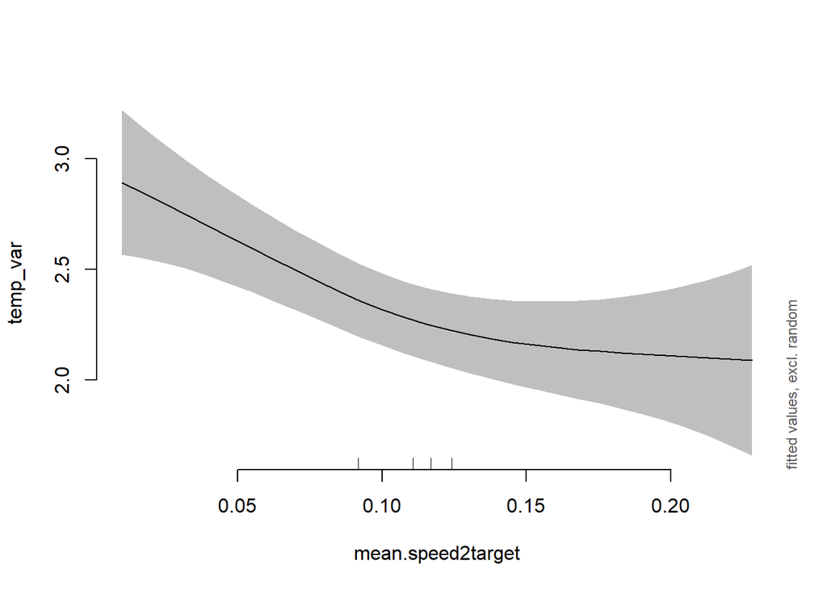

```r
plot_smooth(m2, view = "mean.speed2target")
```

Variable pattern.

Separate per group, using ordered factor?

```r
summary(m3 <- bam(temp_var ~ segO + s(mean.speed2target) + s(mean.speed2target, by = groupO) + groupO + s(mean.speed2target, subj, bs = "fs", m=1, k = 4) + s(mean.speed2target, subj, by = segO, bs = "fs", m=1, k = 4), data = df, family =Gamma(link=log), discrete = T, nthreads = 10))
```

```
##
## Family: Gamma
## Link function: log
##
## Formula:
## temp_var ~ segO + s(mean.speed2target) + s(mean.speed2target,
##     by = groupO) + groupO + s(mean.speed2target, subj, bs = "fs",
##     m = 1, k = 4) + s(mean.speed2target, subj, by = segO, bs = "fs",
##     m = 1, k = 4)
##
## Parametric coefficients:
##               Estimate Std. Error t value Pr(>|t|)
## (Intercept)    2.78564    0.08721  31.943  < 2e-16 ***
## segOK         -0.06525    0.07345  -0.888  0.37501
## segOT         -0.03417    0.06998  -0.488  0.62577
## groupOtypical -0.32609    0.11731  -2.780  0.00577 **
## ---
## Signif. codes:  0 '***' 0.001 '**' 0.01 '*' 0.05 '.' 0.1 ' ' 1
##
## Approximate significance of smooth terms:
##                                       edf  Ref.df      F  p-value
## s(mean.speed2target)                1.000   1.000 15.943 8.17e-05 ***
## s(mean.speed2target):groupOtypical  2.105   2.481  2.740   0.0626 .
## s(mean.speed2target,subj)          35.411 159.000  1.127  < 2e-16 ***
## s(mean.speed2target,subj):segOK    19.175 109.000  0.355 1.72e-05 ***
## s(mean.speed2target,subj):segOT    24.824 132.000  0.391 2.54e-06 ***
## ---
## Signif. codes:  0 '***' 0.001 '**' 0.01 '*' 0.05 '.' 0.1 ' ' 1
##
## R-sq.(adj) =  0.527   Deviance explained = 66.9%
## fREML = 267.24  Scale est. = 0.14064   n = 397
```

No.

Add pace? (fitting with discrete = T, all smooths considered as random effects)

```r
summary(m.alt <- bam(temp_var ~ segO + s(mean.speed2target) + groupO + s(mean.gest.dur) + s(mean.gest.dur, by = groupO) +  s(mean.speed2target, subj, bs = "fs", m=1, k = 4) + s(mean.speed2target, subj, by = segO, bs = "fs", m=1, k = 4)+  s(mean.gest.dur, subj, bs = "fs", m=1, k = 4) + s(mean.gest.dur, subj, by = segO, bs = "fs", m=1, k = 4), data = df, family =Gamma(link=log), select = T, discrete = T, nthreads = 10))
```

```
##
## Family: Gamma
## Link function: log
##
## Formula:
## temp_var ~ segO + s(mean.speed2target) + groupO + s(mean.gest.dur) +
##     s(mean.gest.dur, by = groupO) + s(mean.speed2target, subj,
##     bs = "fs", m = 1, k = 4) + s(mean.speed2target, subj, by = segO,
##     bs = "fs", m = 1, k = 4) + s(mean.gest.dur, subj, bs = "fs",
##     m = 1, k = 4) + s(mean.gest.dur, subj, by = segO, bs = "fs",
##     m = 1, k = 4)
##
## Parametric coefficients:
##               Estimate Std. Error t value Pr(>|t|)
## (Intercept)    2.82409    0.07976  35.406   <2e-16 ***
## segOK         -0.14478    0.07321  -1.978   0.0489 *
## segOT         -0.08626    0.07016  -1.229   0.2199
## groupOtypical -0.23835    0.10788  -2.209   0.0279 *
## ---
## Signif. codes:  0 '***' 0.001 '**' 0.01 '*' 0.05 '.' 0.1 ' ' 1
##
## Approximate significance of smooth terms:
##                                       edf Ref.df     F  p-value
## s(mean.speed2target)            2.329e+00      9 3.216  < 2e-16 ***
## s(mean.gest.dur)                3.117e-05      9 0.000 0.303673
## s(mean.gest.dur):groupOtypical  9.469e-01      9 1.980  < 2e-16 ***
## s(mean.speed2target,subj)       2.009e+01    159 0.187  < 2e-16 ***
## s(mean.speed2target,subj):segOK 1.687e+01    109 0.284 4.08e-05 ***
## s(mean.speed2target,subj):segOT 1.804e+01    132 0.237 2.54e-06 ***
## s(mean.gest.dur,subj)           2.128e+01    159 0.209  < 2e-16 ***
## s(mean.gest.dur,subj):segOK     5.072e-05    119 0.000 0.025606 *
## s(mean.gest.dur,subj):segOT     8.993e+00    130 0.084 0.000677 ***
## ---
## Signif. codes:  0 '***' 0.001 '**' 0.01 '*' 0.05 '.' 0.1 ' ' 1
##
## R-sq.(adj) =  0.563   Deviance explained = 69.6%
## fREML =  256.8  Scale est. = 0.13331   n = 397
```

```r
summary(m.alt2 <- bam(temp_var ~ segO + s(mean.speed2target) + groupO + s(mean.gest.dur) + s(mean.gest.dur, by = groupO) + s(pace) + s(mean.speed2target, subj, bs = "fs", m=1, k = 4) + s(mean.speed2target, subj, by = segO, bs = "fs", m=1, k = 4)+  s(mean.gest.dur, subj, bs = "fs", m=1, k = 4) + s(mean.gest.dur, subj, by = segO, bs = "fs", m=1, k = 4), data = df, family =Gamma(link=log), select = T, discrete = T, nthreads = 10))
```

```
##
## Family: Gamma
## Link function: log
##
## Formula:
## temp_var ~ segO + s(mean.speed2target) + groupO + s(mean.gest.dur) +
##     s(mean.gest.dur, by = groupO) + s(pace) + s(mean.speed2target,
##     subj, bs = "fs", m = 1, k = 4) + s(mean.speed2target, subj,
##     by = segO, bs = "fs", m = 1, k = 4) + s(mean.gest.dur, subj,
##     bs = "fs", m = 1, k = 4) + s(mean.gest.dur, subj, by = segO,
##     bs = "fs", m = 1, k = 4)
##
## Parametric coefficients:
##               Estimate Std. Error t value Pr(>|t|)
## (Intercept)    2.83995    0.07760  36.596   <2e-16 ***
## segOK         -0.20530    0.08093  -2.537   0.0117 *
## segOT         -0.13184    0.07466  -1.766   0.0784 .
## groupOtypical -0.23513    0.10634  -2.211   0.0278 *
## ---
## Signif. codes:  0 '***' 0.001 '**' 0.01 '*' 0.05 '.' 0.1 ' ' 1
##
## Approximate significance of smooth terms:
##                                       edf Ref.df     F  p-value
## s(mean.speed2target)            2.414e+00      9 3.556  < 2e-16 ***
## s(mean.gest.dur)                3.774e-05      9 0.000 0.136279
## s(mean.gest.dur):groupOtypical  9.094e-01      9 1.115 2.78e-06 ***
## s(pace)                         2.130e+00      9 0.739 0.001009 **
## s(mean.speed2target,subj)       2.012e+01    159 0.190  < 2e-16 ***
## s(mean.speed2target,subj):segOK 1.776e+01    109 0.306 2.55e-05 ***
## s(mean.speed2target,subj):segOT 1.874e+01    132 0.254 9.75e-07 ***
## s(mean.gest.dur,subj)           1.719e+01    159 0.168  < 2e-16 ***
## s(mean.gest.dur,subj):segOK     5.935e-05    119 0.000 0.020973 *
## s(mean.gest.dur,subj):segOT     1.063e+01    130 0.104 0.000393 ***
## ---
## Signif. codes:  0 '***' 0.001 '**' 0.01 '*' 0.05 '.' 0.1 ' ' 1
##
## R-sq.(adj) =   0.57   Deviance explained = 70.2%
## fREML = 255.78  Scale est. = 0.13054   n = 397
```

```r
compareML(m.alt, m.alt2)
```

```
## m.alt: temp_var ~ segO + s(mean.speed2target) + groupO + s(mean.gest.dur) +
##     s(mean.gest.dur, by = groupO) + s(mean.speed2target, subj,
##     bs = "fs", m = 1, k = 4) + s(mean.speed2target, subj, by = segO,
##     bs = "fs", m = 1, k = 4) + s(mean.gest.dur, subj, bs = "fs",
##     m = 1, k = 4) + s(mean.gest.dur, subj, by = segO, bs = "fs",
##     m = 1, k = 4)
##
## m.alt2: temp_var ~ segO + s(mean.speed2target) + groupO + s(mean.gest.dur) +
##     s(mean.gest.dur, by = groupO) + s(pace) + s(mean.speed2target,
##     subj, bs = "fs", m = 1, k = 4) + s(mean.speed2target, subj,
##     by = segO, bs = "fs", m = 1, k = 4) + s(mean.gest.dur, subj,
##     bs = "fs", m = 1, k = 4) + s(mean.gest.dur, subj, by = segO,
##     bs = "fs", m = 1, k = 4)
##
## Chi-square test of fREML scores
## -----
##    Model    Score Edf Difference    Df p.value Sig.
## 1  m.alt 256.7989  22
## 2 m.alt2 255.7776  24      1.021 2.000   0.360
##
## AIC difference: 4.66, model m.alt2 has lower AIC.
```

Add random smooth per seg over pace?

```r
summary(m4Random <- bam(temp_var ~ segO + s(pace) + groupO + s(mean.speed2target) +  s(mean.speed2target, subj, bs = "fs", m=1, k = 4) + s(mean.speed2target, subj, by = segO, bs = "fs", m=1, k = 4) + s(pace, subj, bs = "fs", m=1, k = 4) + s(pace, subj, by = segO, bs = "fs", m=1, k = 4), data = df, family =Gamma(link=log), discrete = T, nthreads = 10))
```

```
##
## Family: Gamma
## Link function: log
##
## Formula:
## temp_var ~ segO + s(pace) + groupO + s(mean.speed2target) + s(mean.speed2target,
##     subj, bs = "fs", m = 1, k = 4) + s(mean.speed2target, subj,
##     by = segO, bs = "fs", m = 1, k = 4) + s(pace, subj, bs = "fs",
##     m = 1, k = 4) + s(pace, subj, by = segO, bs = "fs", m = 1,
##     k = 4)
##
## Parametric coefficients:
##               Estimate Std. Error t value Pr(>|t|)
## (Intercept)    2.83859    0.08059  35.223  < 2e-16 ***
## segOK         -0.25931    0.08422  -3.079  0.00227 **
## segOT         -0.15484    0.07498  -2.065  0.03979 *
## groupOtypical -0.22076    0.10999  -2.007  0.04564 *
## ---
## Signif. codes:  0 '***' 0.001 '**' 0.01 '*' 0.05 '.' 0.1 ' ' 1
##
## Approximate significance of smooth terms:
##                                    edf  Ref.df      F  p-value
## s(pace)                          2.287   2.731  5.405 0.001515 **
## s(mean.speed2target)             2.723   3.229 12.263  < 2e-16 ***
## s(mean.speed2target,subj)       16.606 159.000  0.147  < 2e-16 ***
## s(mean.speed2target,subj):segOK 12.958 112.000  0.177 3.92e-05 ***
## s(mean.speed2target,subj):segOT 18.325 132.000  0.236 1.71e-06 ***
## s(pace,subj)                    28.147 159.000  0.302  < 2e-16 ***
## s(pace,subj):segOK               5.687 115.000  0.059 0.000808 ***
## s(pace,subj):segOT               7.724 128.000  0.071 0.000193 ***
## ---
## Signif. codes:  0 '***' 0.001 '**' 0.01 '*' 0.05 '.' 0.1 ' ' 1
##
## R-sq.(adj) =  0.555   Deviance explained = 70.8%
## fREML = 258.74  Scale est. = 0.13056   n = 397
```

Yes.

Add pace per group?

```r
summary(m5 <- bam(temp_var ~ segO + s(pace) + s(pace, by = groupO) + groupO + s(mean.speed2target) +  s(mean.speed2target, subj, bs = "fs", m=1, k = 4) + s(mean.speed2target, subj, by = segO, bs = "fs", m=1, k = 4) +  s(pace, subj, bs = "fs", m=1, k = 4) + s(pace, subj, by = segO, bs = "fs", m=1, k = 4), data = df, family =Gamma(link=log), discrete = T, nthreads = 10))
```

```
##
## Family: Gamma
## Link function: log
##
## Formula:
## temp_var ~ segO + s(pace) + s(pace, by = groupO) + groupO + s(mean.speed2target) +
##     s(mean.speed2target, subj, bs = "fs", m = 1, k = 4) + s(mean.speed2target,
##     subj, by = segO, bs = "fs", m = 1, k = 4) + s(pace, subj,
##     bs = "fs", m = 1, k = 4) + s(pace, subj, by = segO, bs = "fs",
##     m = 1, k = 4)
##
## Parametric coefficients:
##               Estimate Std. Error t value Pr(>|t|)
## (Intercept)    2.84972    0.07959  35.806  < 2e-16 ***
## segOK         -0.24233    0.08262  -2.933  0.00361 **
## segOT         -0.13918    0.07355  -1.892  0.05941 .
## groupOtypical -0.23085    0.10839  -2.130  0.03400 *
## ---
## Signif. codes:  0 '***' 0.001 '**' 0.01 '*' 0.05 '.' 0.1 ' ' 1
##
## Approximate significance of smooth terms:
##                                    edf  Ref.df      F  p-value
## s(pace)                          2.715   3.281  1.809 0.149850
## s(pace):groupOtypical            1.000   1.000  7.666 0.005976 **
## s(mean.speed2target)             2.487   2.934 11.275 1.12e-06 ***
## s(mean.speed2target,subj)       20.197 159.000  0.184  < 2e-16 ***
## s(mean.speed2target,subj):segOK 14.831 113.000  0.216 3.37e-05 ***
## s(mean.speed2target,subj):segOT 20.946 132.000  0.294 9.44e-07 ***
## s(pace,subj)                    23.216 159.000  0.235  < 2e-16 ***
## s(pace,subj):segOK               2.503 116.000  0.023 0.003281 **
## s(pace,subj):segOT               4.380 128.000  0.038 0.000475 ***
## ---
## Signif. codes:  0 '***' 0.001 '**' 0.01 '*' 0.05 '.' 0.1 ' ' 1
##
## R-sq.(adj) =  0.556   Deviance explained = 70.6%
## fREML = 256.91  Scale est. = 0.12971   n = 397
```

Yes.

Plot smooths:

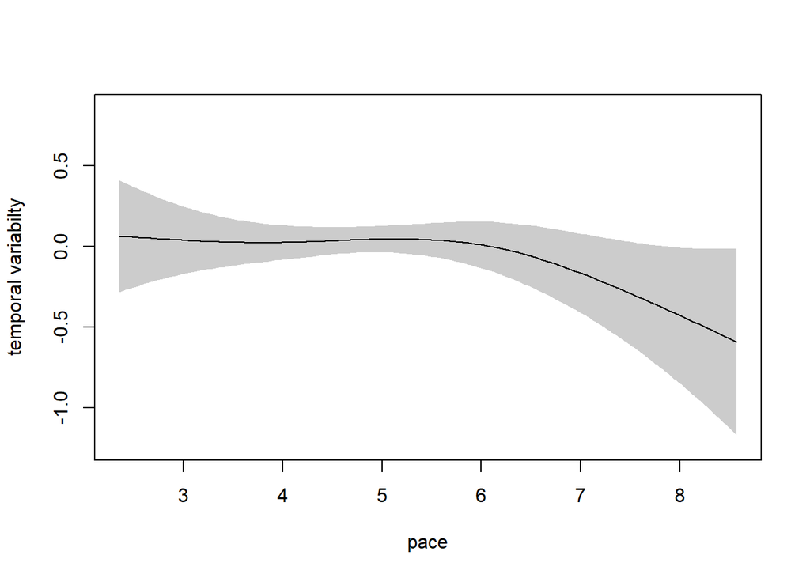

```r
plot(m5, select = 1, shade = T, ylab = "temporal variabilty", rug=F)
```

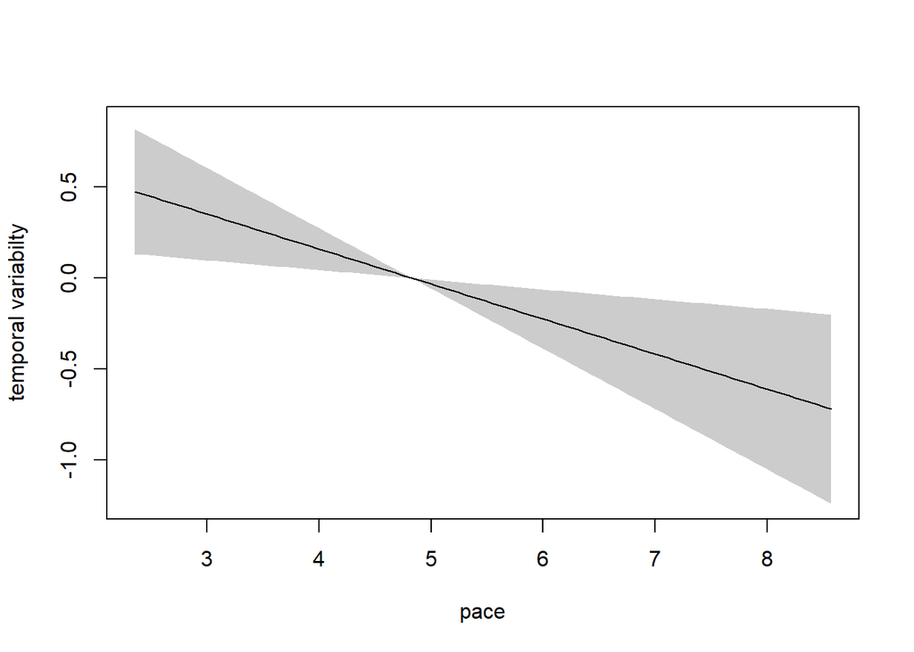

```r
plot(m5, select = 2, shade = T, ylab = "temporal variabilty", rug=F)
```

Check whether we can add another predictor in addition to speed2target (including appropriate random smooths, compare based on R-squared)

```r
summary(m5gest.dur <- bam(temp_var ~ segO + s(pace) + s(pace, by = groupO) + groupO + s(mean.speed2target) + s(mean.gest.dur) + s(mean.speed2target, subj, bs = "fs", m=1, k = 4) + s(mean.speed2target, subj, by = segO, bs = "fs", m=1, k = 4) +  s(pace, subj, bs = "fs", m=1, k = 4) + s(pace, subj, by = segO, bs = "fs", m=1, k = 4), data = df, family =Gamma(link=log), discrete = T, nthreads = 10))
```

```
##
## Family: Gamma
## Link function: log
##
## Formula:
## temp_var ~ segO + s(pace) + s(pace, by = groupO) + groupO + s(mean.speed2target) +
##     s(mean.gest.dur) + s(mean.speed2target, subj, bs = "fs",
##     m = 1, k = 4) + s(mean.speed2target, subj, by = segO, bs = "fs",
##     m = 1, k = 4) + s(pace, subj, bs = "fs", m = 1, k = 4) +
##     s(pace, subj, by = segO, bs = "fs", m = 1, k = 4)
##
## Parametric coefficients:
##               Estimate Std. Error t value Pr(>|t|)
## (Intercept)    2.85153    0.08093  35.236  < 2e-16 ***
## segOK         -0.24352    0.08405  -2.897  0.00404 **
## segOT         -0.13328    0.07244  -1.840  0.06679 .
## groupOtypical -0.24255    0.11002  -2.205  0.02824 *
## ---
## Signif. codes:  0 '***' 0.001 '**' 0.01 '*' 0.05 '.' 0.1 ' ' 1
##
## Approximate significance of smooth terms:
##                                    edf  Ref.df      F  p-value
## s(pace)                          1.197   1.298  0.253  0.79226
## s(pace):groupOtypical            1.000   1.000  8.462  0.00390 **
## s(mean.speed2target)             2.540   3.005 10.153 2.79e-06 ***
## s(mean.gest.dur)                 4.135   4.981  1.846  0.10545
## s(mean.speed2target,subj)       18.619 159.000  0.168  < 2e-16 ***
## s(mean.speed2target,subj):segOK 11.829 113.000  0.153 9.91e-05 ***
## s(mean.speed2target,subj):segOT 21.447 132.000  0.308 1.51e-06 ***
## s(pace,subj)                    24.693 159.000  0.255  < 2e-16 ***
## s(pace,subj):segOK               5.807 116.000  0.059  0.00125 **
## s(pace,subj):segOT               2.909 123.000  0.026  0.00074 ***
## ---
## Signif. codes:  0 '***' 0.001 '**' 0.01 '*' 0.05 '.' 0.1 ' ' 1
##
## R-sq.(adj) =  0.565   Deviance explained = 71.2%
## fREML =  256.9  Scale est. = 0.12749   n = 397
```

```r
summary(m5accphase <- bam(temp_var ~ segO + s(pace) + s(pace, by = groupO) + groupO + s(mean.speed2target) + s(mean.dur.accphase) + s(mean.speed2target, subj, bs = "fs", m=1, k = 4) + s(mean.speed2target, subj, by = segO, bs = "fs", m=1, k = 4) +  s(pace, subj, bs = "fs", m=1, k = 4) + s(pace, subj, by = segO, bs = "fs", m=1, k = 4), data = df, family =Gamma(link=log), discrete = T, nthreads = 10))
```

```
##
## Family: Gamma
## Link function: log
##
## Formula:
## temp_var ~ segO + s(pace) + s(pace, by = groupO) + groupO + s(mean.speed2target) +
##     s(mean.dur.accphase) + s(mean.speed2target, subj, bs = "fs",
##     m = 1, k = 4) + s(mean.speed2target, subj, by = segO, bs = "fs",
##     m = 1, k = 4) + s(pace, subj, bs = "fs", m = 1, k = 4) +
##     s(pace, subj, by = segO, bs = "fs", m = 1, k = 4)
##
## Parametric coefficients:
##               Estimate Std. Error t value Pr(>|t|)
## (Intercept)    2.85701    0.08041  35.532  < 2e-16 ***
## segOK         -0.24236    0.08288  -2.924  0.00372 **
## segOT         -0.12891    0.07446  -1.731  0.08443 .
## groupOtypical -0.22374    0.10964  -2.041  0.04215 *
## ---
## Signif. codes:  0 '***' 0.001 '**' 0.01 '*' 0.05 '.' 0.1 ' ' 1
##
## Approximate significance of smooth terms:
##                                    edf  Ref.df      F  p-value
## s(pace)                          2.817   3.435  1.870 0.137179
## s(pace):groupOtypical            1.000   1.000  8.077 0.004788 **
## s(mean.speed2target)             2.502   2.954 11.334 9.11e-07 ***
## s(mean.dur.accphase)             1.000   1.000  0.497 0.481181
## s(mean.speed2target,subj)       19.702 159.000  0.179  < 2e-16 ***
## s(mean.speed2target,subj):segOK 14.292 113.000  0.204 4.24e-05 ***
## s(mean.speed2target,subj):segOT 21.416 132.000  0.306 1.10e-06 ***
## s(pace,subj)                    23.221 159.000  0.236  < 2e-16 ***
## s(pace,subj):segOK               3.067 116.000  0.029 0.002879 **
## s(pace,subj):segOT               3.301 128.000  0.028 0.000553 ***
## ---
## Signif. codes:  0 '***' 0.001 '**' 0.01 '*' 0.05 '.' 0.1 ' ' 1
##
## R-sq.(adj) =  0.554   Deviance explained = 70.5%
## fREML = 258.27  Scale est. = 0.13039   n = 397
```

```r
summary(m5decphase <- bam(temp_var ~ segO + s(pace) + s(pace, by = groupO) + groupO + s(mean.speed2target) + s(mean.dur.decphase) + s(mean.speed2target, subj, bs = "fs", m=1, k = 4) + s(mean.speed2target, subj, by = segO, bs = "fs", m=1, k = 4) +  s(pace, subj, bs = "fs", m=1, k = 4) + s(pace, subj, by = segO, bs = "fs", m=1, k = 4), data = df, family =Gamma(link=log), discrete = T, nthreads = 10))
```

```
##
## Family: Gamma
## Link function: log
##
## Formula:
## temp_var ~ segO + s(pace) + s(pace, by = groupO) + groupO + s(mean.speed2target) +
##     s(mean.dur.decphase) + s(mean.speed2target, subj, bs = "fs",
##     m = 1, k = 4) + s(mean.speed2target, subj, by = segO, bs = "fs",
##     m = 1, k = 4) + s(pace, subj, bs = "fs", m = 1, k = 4) +
##     s(pace, subj, by = segO, bs = "fs", m = 1, k = 4)
##
## Parametric coefficients:
##               Estimate Std. Error t value Pr(>|t|)
## (Intercept)    2.83460    0.08242  34.390   <2e-16 ***
## segOK         -0.21128    0.08319  -2.540   0.0116 *
## segOT         -0.10097    0.07358  -1.372   0.1710
## groupOtypical -0.23435    0.11126  -2.106   0.0360 *
## ---
## Signif. codes:  0 '***' 0.001 '**' 0.01 '*' 0.05 '.' 0.1 ' ' 1
##
## Approximate significance of smooth terms:
##                                    edf  Ref.df     F  p-value
## s(pace)                          2.411   2.912 1.382 0.191028
## s(pace):groupOtypical            1.000   1.000 8.375 0.004083 **
## s(mean.speed2target)             2.521   2.984 9.793 4.09e-06 ***
## s(mean.dur.decphase)             2.884   3.544 1.911 0.123218
## s(mean.speed2target,subj)       17.490 159.000 0.159  < 2e-16 ***
## s(mean.speed2target,subj):segOK 12.769 113.000 0.171 0.000128 ***
## s(mean.speed2target,subj):segOT 22.322 132.000 0.332 9.49e-07 ***
## s(pace,subj)                    25.303 159.000 0.264  < 2e-16 ***
## s(pace,subj):segOK               4.249 116.000 0.041 0.002458 **
## s(pace,subj):segOT               2.702 125.000 0.023 0.000855 ***
## ---
## Signif. codes:  0 '***' 0.001 '**' 0.01 '*' 0.05 '.' 0.1 ' ' 1
##
## R-sq.(adj) =  0.563   Deviance explained = 71.1%
## fREML =  256.8  Scale est. = 0.1279    n = 397
```

```r
summary(m5time2target <- bam(temp_var ~ segO + s(pace) + s(pace, by = groupO) + groupO + s(mean.speed2target) + s(mean.time2target) + s(mean.speed2target, subj, bs = "fs", m=1, k = 4) + s(mean.speed2target, subj, by = segO, bs = "fs", m=1, k = 4) +  s(pace, subj, bs = "fs", m=1, k = 4) + s(pace, subj, by = segO, bs = "fs", m=1, k = 4), data = df, family =Gamma(link=log), discrete = T, nthreads = 10))
```

```
##
## Family: Gamma
## Link function: log
##
## Formula:
## temp_var ~ segO + s(pace) + s(pace, by = groupO) + groupO + s(mean.speed2target) +
##     s(mean.time2target) + s(mean.speed2target, subj, bs = "fs",
##     m = 1, k = 4) + s(mean.speed2target, subj, by = segO, bs = "fs",
##     m = 1, k = 4) + s(pace, subj, bs = "fs", m = 1, k = 4) +
##     s(pace, subj, by = segO, bs = "fs", m = 1, k = 4)
##
## Parametric coefficients:
##               Estimate Std. Error t value Pr(>|t|)
## (Intercept)    2.85135    0.08113  35.147  < 2e-16 ***
## segOK         -0.22969    0.08326  -2.759  0.00616 **
## segOT         -0.12668    0.07366  -1.720  0.08649 .
## groupOtypical -0.23727    0.11014  -2.154  0.03201 *
## ---
## Signif. codes:  0 '***' 0.001 '**' 0.01 '*' 0.05 '.' 0.1 ' ' 1
##
## Approximate significance of smooth terms:
##                                    edf  Ref.df      F  p-value
## s(pace)                          2.627   3.185  1.798 0.165490
## s(pace):groupOtypical            1.000   1.000  8.399 0.004030 **
## s(mean.speed2target)             2.478   2.926 10.084 4.14e-06 ***
## s(mean.time2target)              1.845   2.239  0.347 0.593282
## s(mean.speed2target,subj)       18.910 159.000  0.172  < 2e-16 ***
## s(mean.speed2target,subj):segOK 13.922 113.000  0.195 5.13e-05 ***
## s(mean.speed2target,subj):segOT 21.892 132.000  0.319 1.04e-06 ***
## s(pace,subj)                    24.077 159.000  0.248  < 2e-16 ***
## s(pace,subj):segOK               3.698 116.000  0.036 0.002340 **
## s(pace,subj):segOT               2.844 126.000  0.025 0.000726 ***
## ---
## Signif. codes:  0 '***' 0.001 '**' 0.01 '*' 0.05 '.' 0.1 ' ' 1
##
## R-sq.(adj) =  0.559   Deviance explained = 70.8%
## fREML = 257.82  Scale est. = 0.12932   n = 397
```

```r
summary(m5displacement <- bam(temp_var ~ segO + s(pace) + s(pace, by = groupO) + groupO + s(mean.speed2target) + s(mean.dist2target) + s(mean.speed2target, subj, bs = "fs", m=1, k = 4) + s(mean.speed2target, subj, by = segO, bs = "fs", m=1, k = 4) +  s(pace, subj, bs = "fs", m=1, k = 4) + s(pace, subj, by = segO, bs = "fs", m=1, k = 4), data = df, family =Gamma(link=log), discrete = T, nthreads = 10))
```

```
##
## Family: Gamma
## Link function: log
##
## Formula:
## temp_var ~ segO + s(pace) + s(pace, by = groupO) + groupO + s(mean.speed2target) +
##     s(mean.dist2target) + s(mean.speed2target, subj, bs = "fs",
##     m = 1, k = 4) + s(mean.speed2target, subj, by = segO, bs = "fs",
##     m = 1, k = 4) + s(pace, subj, bs = "fs", m = 1, k = 4) +
##     s(pace, subj, by = segO, bs = "fs", m = 1, k = 4)
##
## Parametric coefficients:
##               Estimate Std. Error t value Pr(>|t|)
## (Intercept)    2.84779    0.08030  35.466  < 2e-16 ***
## segOK         -0.24089    0.08278  -2.910  0.00389 **
## segOT         -0.13828    0.07357  -1.880  0.06113 .
## groupOtypical -0.23211    0.10930  -2.124  0.03451 *
## ---
## Signif. codes:  0 '***' 0.001 '**' 0.01 '*' 0.05 '.' 0.1 ' ' 1
##
## Approximate significance of smooth terms:
##                                    edf  Ref.df     F  p-value
## s(pace)                          2.808   3.433 1.844 0.141706
## s(pace):groupOtypical            1.000   1.000 7.464 0.006667 **
## s(mean.speed2target)             2.408   2.844 3.651 0.010874 *
## s(mean.dist2target)              1.000   1.000 0.122 0.727281
## s(mean.speed2target,subj)       20.730 159.000 0.190  < 2e-16 ***
## s(mean.speed2target,subj):segOK 14.842 113.000 0.217 3.12e-05 ***
## s(mean.speed2target,subj):segOT 21.338 132.000 0.303 9.51e-07 ***
## s(pace,subj)                    22.687 159.000 0.229  < 2e-16 ***
## s(pace,subj):segOK               2.395 116.000 0.022 0.003577 **
## s(pace,subj):segOT               3.566 128.000 0.031 0.000482 ***
## ---
## Signif. codes:  0 '***' 0.001 '**' 0.01 '*' 0.05 '.' 0.1 ' ' 1
##
## R-sq.(adj) =  0.555   Deviance explained = 70.6%
## fREML = 257.72  Scale est. = 0.12995   n = 397
```

```r
summary(m5peakvel <- bam(temp_var ~ segO + s(pace) + s(pace, by = groupO) + groupO + s(mean.speed2target) + s(mean.peakvel2target) + s(mean.speed2target, subj, bs = "fs", m=1, k = 4) + s(mean.speed2target, subj, by = segO, bs = "fs", m=1, k = 4) +  s(pace, subj, bs = "fs", m=1, k = 4) + s(pace, subj, by = segO, bs = "fs", m=1, k = 4), data = df, family =Gamma(link=log), discrete = T, nthreads = 10))
```

```
##
## Family: Gamma
## Link function: log
##
## Formula:
## temp_var ~ segO + s(pace) + s(pace, by = groupO) + groupO + s(mean.speed2target) +
##     s(mean.peakvel2target) + s(mean.speed2target, subj, bs = "fs",
##     m = 1, k = 4) + s(mean.speed2target, subj, by = segO, bs = "fs",
##     m = 1, k = 4) + s(pace, subj, bs = "fs", m = 1, k = 4) +
##     s(pace, subj, by = segO, bs = "fs", m = 1, k = 4)
##
## Parametric coefficients:
##               Estimate Std. Error t value Pr(>|t|)
## (Intercept)    2.85118    0.07989  35.687  < 2e-16 ***
## segOK         -0.24412    0.08696  -2.807  0.00533 **
## segOT         -0.13905    0.07363  -1.888  0.05994 .
## groupOtypical -0.23319    0.10956  -2.128  0.03412 *
## ---
## Signif. codes:  0 '***' 0.001 '**' 0.01 '*' 0.05 '.' 0.1 ' ' 1
##
## Approximate significance of smooth terms:
##                                    edf  Ref.df     F  p-value
## s(pace)                          2.710   3.287 1.814 0.148968
## s(pace):groupOtypical            1.000   1.000 7.609 0.006163 **
## s(mean.speed2target)             2.488   2.935 2.063 0.085138 .
## s(mean.peakvel2target)           1.000   1.000 0.003 0.956938
## s(mean.speed2target,subj)       20.170 159.000 0.184  < 2e-16 ***
## s(mean.speed2target,subj):segOK 14.668 113.000 0.213 3.18e-05 ***
## s(mean.speed2target,subj):segOT 21.247 132.000 0.299 1.07e-06 ***
## s(pace,subj)                    23.185 159.000 0.235  < 2e-16 ***
## s(pace,subj):segOK               2.649 116.000 0.025 0.003256 **
## s(pace,subj):segOT               3.844 128.000 0.033 0.000471 ***
## ---
## Signif. codes:  0 '***' 0.001 '**' 0.01 '*' 0.05 '.' 0.1 ' ' 1
##
## R-sq.(adj) =  0.554   Deviance explained = 70.6%
## fREML = 256.94  Scale est. = 0.12995   n = 397
```

```r
summary(m5stiffnes <- bam(temp_var ~ segO + s(pace) + s(pace, by = groupO) + groupO + s(mean.speed2target) + s(mean.stiffness2target) + s(mean.speed2target, subj, bs = "fs", m=1, k = 4) + s(mean.speed2target, subj, by = segO, bs = "fs", m=1, k = 4) +  s(pace, subj, bs = "fs", m=1, k = 4) + s(pace, subj, by = segO, bs = "fs", m=1, k = 4), data = df, family =Gamma(link=log), discrete = T, nthreads = 10))
```

```
##
## Family: Gamma
## Link function: log
##
## Formula:
## temp_var ~ segO + s(pace) + s(pace, by = groupO) + groupO + s(mean.speed2target) +
##     s(mean.stiffness2target) + s(mean.speed2target, subj, bs = "fs",
##     m = 1, k = 4) + s(mean.speed2target, subj, by = segO, bs = "fs",
##     m = 1, k = 4) + s(pace, subj, bs = "fs", m = 1, k = 4) +
##     s(pace, subj, by = segO, bs = "fs", m = 1, k = 4)
##
## Parametric coefficients:
##               Estimate Std. Error t value Pr(>|t|)
## (Intercept)    2.84711    0.08038  35.422   <2e-16 ***
## segOK         -0.17418    0.08370  -2.081   0.0383 *
## segOT         -0.13080    0.07209  -1.814   0.0706 .
## groupOtypical -0.25494    0.10953  -2.328   0.0206 *
## ---
## Signif. codes:  0 '***' 0.001 '**' 0.01 '*' 0.05 '.' 0.1 ' ' 1
##
## Approximate significance of smooth terms:
##                                       edf  Ref.df     F  p-value
## s(pace)                         1.000e+00   1.000 6.141 0.013765 *
## s(pace):groupOtypical           1.000e+00   1.000 7.818 0.005510 **
## s(mean.speed2target)            2.386e+00   2.810 8.986 2.53e-05 ***
## s(mean.stiffness2target)        3.435e+00   4.178 3.152 0.014625 *
## s(mean.speed2target,subj)       2.031e+01 159.000 0.186  < 2e-16 ***
## s(mean.speed2target,subj):segOK 1.673e+01 112.000 0.266 2.51e-05 ***
## s(mean.speed2target,subj):segOT 1.860e+01 132.000 0.236 4.47e-06 ***
## s(pace,subj)                    2.588e+01 159.000 0.270  < 2e-16 ***
## s(pace,subj):segOK              2.345e-04 119.000 0.000 0.007076 **
## s(pace,subj):segOT              5.668e+00 128.000 0.050 0.000521 ***
## ---
## Signif. codes:  0 '***' 0.001 '**' 0.01 '*' 0.05 '.' 0.1 ' ' 1
##
## R-sq.(adj) =  0.564   Deviance explained = 71.6%
## fREML = 254.95  Scale est. = 0.12584   n = 397
```

Stifness2target is sign.